# facility-characteristics

UWCHR

2/12/2021

Analyzing detention facility population by facility characteristic: “AS NEEDED” facilities; DMCP-authorized facilities; “Over-72” hour facilities. Also check based on contract type/jurisdiction (may require light cleaning).

Starting with annual ADP. Recall that ADP does not equate to number of people passing through facility. Check book-ins along same lines.

“AS NEEDED” facilities, though more common overall than facilities with reported ICE capacity, held a smaller and diminishing portion of detained people by total average ADP over the period from FY2009 - FY2018:

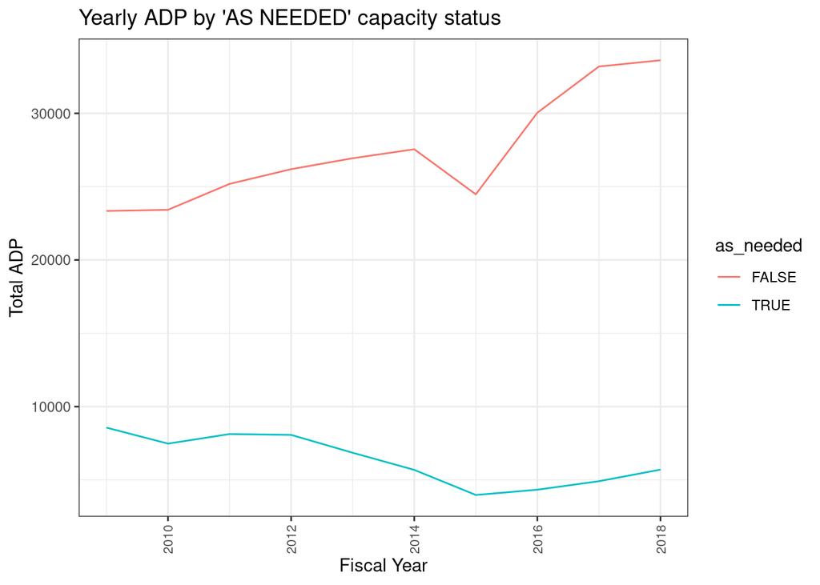

‘AS NEEDED’ yearly ADP per AOR shows varied distributions and trends; ‘AS NEEDED’ ADP tends to be mostly stable year to year, while facilities with known capacity show more notable trends. Note divergence in New Orleans AOR ‘NOL’:

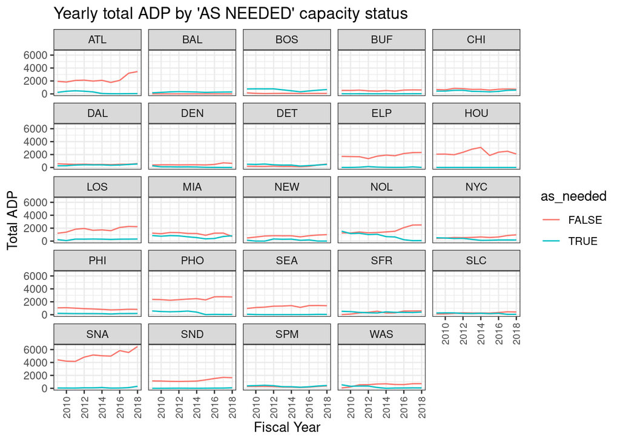

Most AORs held low proportion of population in “AS NEEDED” facilities:

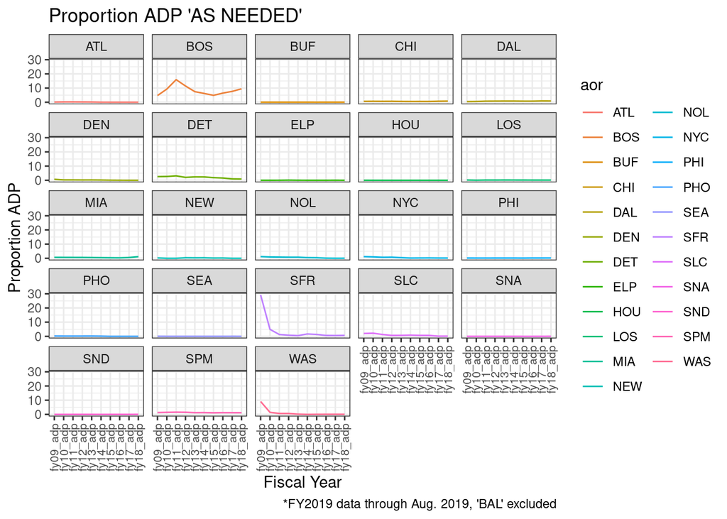

DMCP-authorized facilities held more and increasing number of detained people:

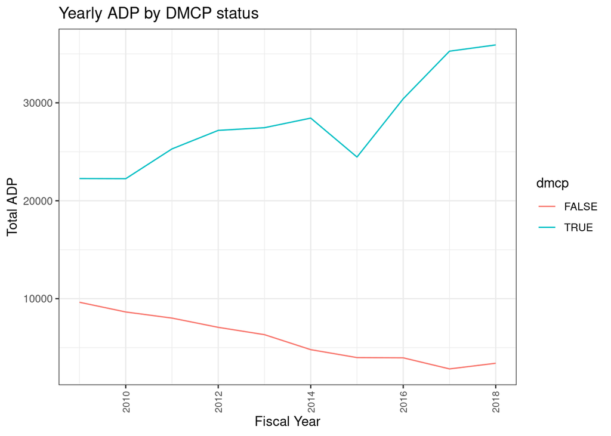

Varied distributions and trends of detained population (ADP) held in DMCP-authorized facilities; most AOR similar to national trend of greater & increasing population in DMCP facilities.

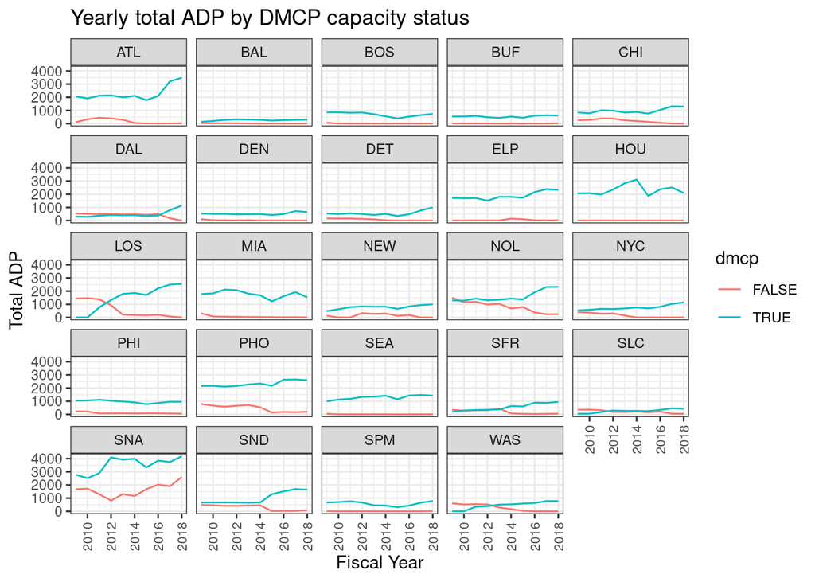

Greater and slightly-increasing proportion of ADP in “Over 72” facilities. Should do some more checking for what facilities with null values in `over_under_72` represent:

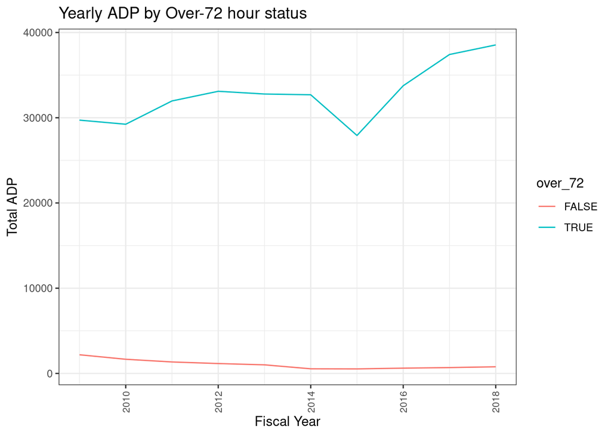

Note expansion of “Over 72” ADP in Atlanta ‘ATL’, San Antonio ‘SNA’ AORs:

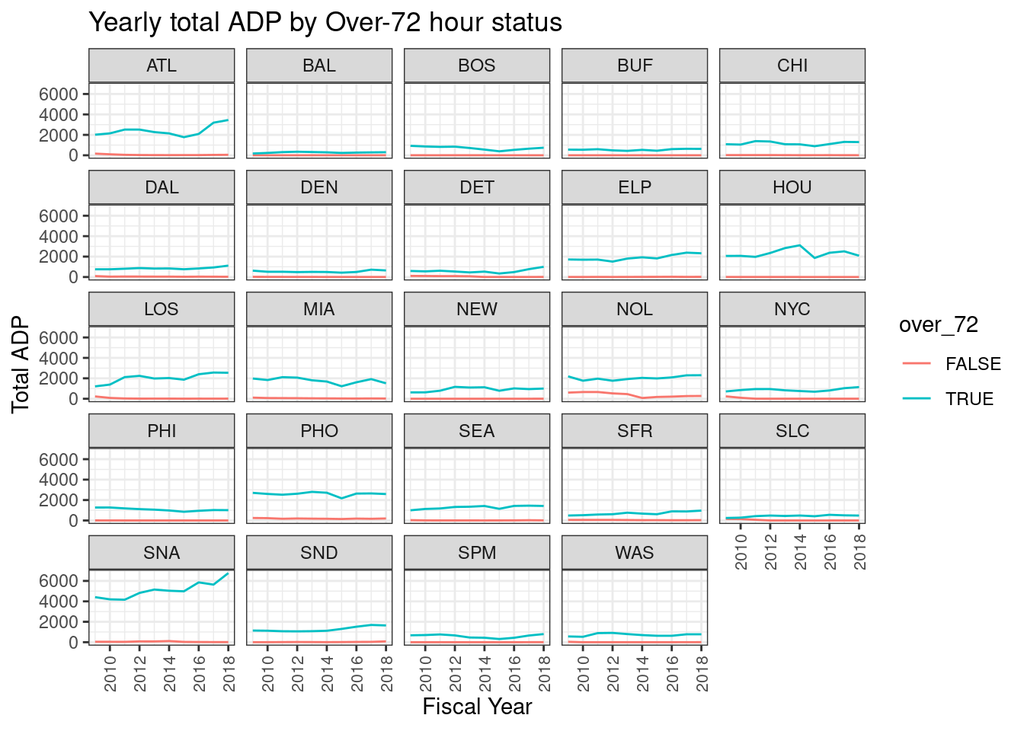